# Exploratory analysis of a GEO dataset

Judit Camps

15/5/2019

# Introduction

In this practical we will do an analysis of a dataset obtained from GEO.

# Summary

The study entitled as ‘Endometrial gene expression in fertile and subfertile cows’ was done using Bos taurus and the experiment type was expression profiling by array.

The summary of the study is *In order to clarify the cause of reproductive failure, we conducted global endometrial gene expression analysis in fertile and subfertile cows. Hierarchical cluster analysis with the expression levels of mitochondrial DNA encoded genes was divided these cows into two clusters. One cluster was composed of fertile cows, the other cluster contained subfertile cows, and the expressions of mitochondrial DNA encoded genes in subfertile cows were higher than those in fertile cows.*

### Experimental design:

To clarify differences in gene expression patterns of the endometrium between fertile and subfertile cows, endometrial biopsy samples were collected from fertile cows (n=6) and subfertile cows (n=5) at day 7 of the estrus cycle. The cows, which became pregnant at ET or AI within 3 times until biopsy and resulted in pregnant at the first ET in the following cycles after biopsy, were used as fertile cows. The subfertile cows were the animals which failed to conceive in three consecutive ET or AI without detectable abnormalities in their genital tracts and with apparently normal estrus cycles before and after biopsy, respectively.

### Citations:

Matsuyama S, Nakamura S, Minabe S, Sakatani M, Takenouchi N, Iwata H, Kimura K

# Data description

We have two files:

- the targets files
- The expression matrix

```r
targets <- read.delim("targets.txt", row.names=NULL)
expression <- as.matrix(read.delim("expression.txt", row.names=1, comment.char="#"))
```

```r
show(targets)
```

```
##    SampleName       Type Replicate Colors
## 1  GSM2877660    Fertile   cow_001      2
## 2  GSM2877661    Fertile   cow_002      2
## 3  GSM2877662    Fertile   cow_003      2
## 4  GSM2877663    Fertile   cow_004      2
## 5  GSM2877664    Fertile   cow_005      2
## 6  GSM2877665    Fertile   cow_006      2
## 7  GSM2877666 Subfertile   cow_001      5
## 8  GSM2877667 Subfertile   cow_002      5
## 9  GSM2877668 Subfertile   cow_003      5
## 10 GSM2877669 Subfertile   cow_004      5
## 11 GSM2877670 Subfertile   cow_005      5
```

```r
dim(expression)
```

```
## [1] 43713    11
```

Once we have read both files, we can now check the type of files they are:

```r
class(targets)
```

```
## [1] "data.frame"
```

```r
class(expression)
```

```
## [1] "matrix"
```

```r
summary(expression)
```

```
##    GSM2877660         GSM2877661         GSM2877662
##  Min.   :-9.31650   Min.   :-6.78773   Min.   :-11.65694
##  1st Qu.:-0.28813   1st Qu.:-0.32976   1st Qu.: -0.29572
##  Median :-0.02230   Median :-0.02733   Median : -0.03536
##  Mean   :-0.04892   Mean   :-0.10647   Mean   : -0.04565
##  3rd Qu.: 0.17414   3rd Qu.: 0.11668   3rd Qu.:  0.18305
##  Max.   : 9.25987   Max.   : 6.27217   Max.   :  8.07427
##    GSM2877663         GSM2877664         GSM2877665
##  Min.   :-7.24179   Min.   :-5.44326   Min.   :-8.23874
##  1st Qu.:-0.29816   1st Qu.:-0.26120   1st Qu.:-0.36566
##  Median :-0.02346   Median :-0.03358   Median :-0.08160
##  Mean   :-0.07519   Mean   :-0.06067   Mean   :-0.09716
##  3rd Qu.: 0.10280   3rd Qu.: 0.11160   3rd Qu.: 0.16972
##  Max.   :13.28794   Max.   : 6.41270   Max.   : 8.00537
##    GSM2877666          GSM2877667         GSM2877668
##  Min.   :-11.07310   Min.   :-5.50214   Min.   :-10.43437
##  1st Qu.: -0.13023   1st Qu.:-0.12327   1st Qu.: -0.11471
##  Median :  0.07483   Median : 0.09184   Median :  0.04669
##  Mean   :  0.13090   Mean   : 0.15157   Mean   :  0.10838
##  3rd Qu.:  0.38032   3rd Qu.: 0.43040   3rd Qu.:  0.37361
##  Max.   : 14.28160   Max.   : 6.46662   Max.   :  5.33577
##    GSM2877669         GSM2877670
##  Min.   :-6.40178   Min.   :-11.20133
##  1st Qu.:-0.13799   1st Qu.: -0.14790
##  Median : 0.02105   Median :  0.08264
##  Mean   : 0.07868   Mean   :  0.15950
##  3rd Qu.: 0.32848   3rd Qu.:  0.44725
##  Max.   : 9.61863   Max.   :  8.81647
```

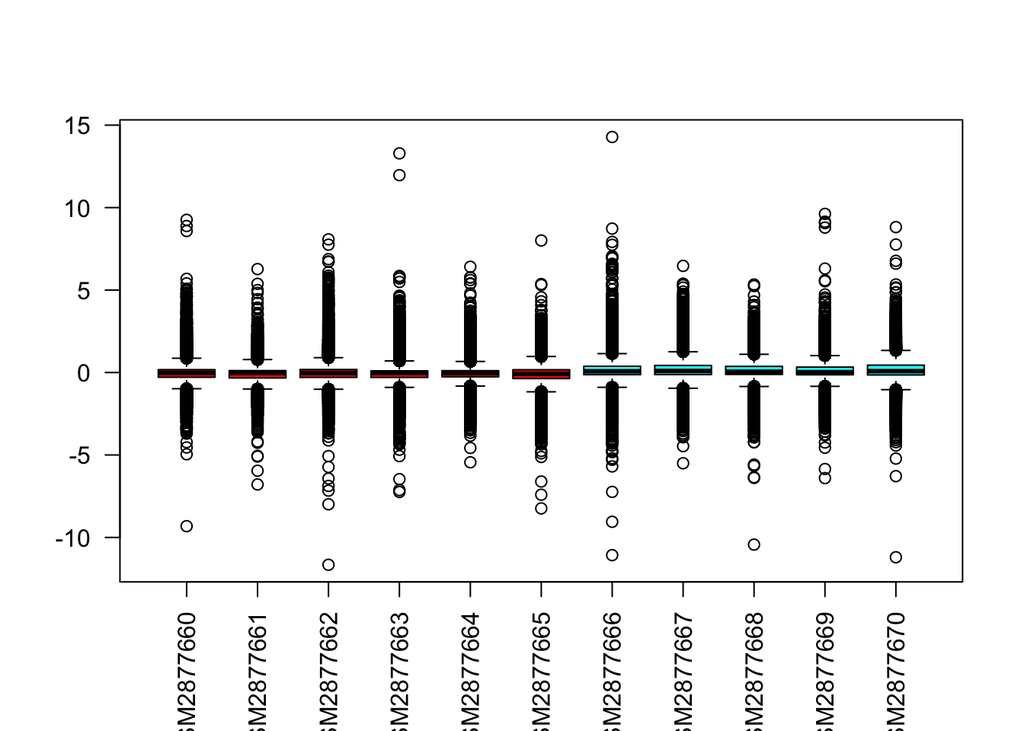

```r
boxplot(expression, las = 2, col=targets$Colors)
```

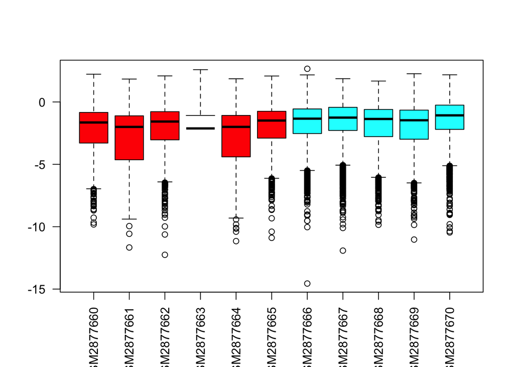

```r
boxplot(log(expression), las = 2, col=targets$Colors)
```

```r
myGenes <- paste0("sample", 1:11)

myInfo=list(myName="Judit Camps", myContact="judit.camps@alum.esci.upf.edu", myTitle="Exercise on Expressionset")
```

```r
library(Biobase)
require(Biobase)
```

```r
expressionValues <- (expression)
myEset <- ExpressionSet(expressionValues)
class(myEset)
```

```
## [1] "ExpressionSet"
## attr(,"package")
## [1] "Biobase"
```

```r
show(myEset)
```

```
## ExpressionSet (storageMode: lockedEnvironment)
## assayData: 43713 features, 11 samples
##   element names: exprs
## protocolData: none
## phenoData: none
## featureData: none
## experimentData: use 'experimentData(object)'
## Annotation:
```

```r
columnDesc <- data.frame(labelDescription= c("SampleName", "Type", "Replicate", "Colors"))

myAnnotDF <- new("AnnotatedDataFrame", data=targets, varMetadata=columnDesc)

show(myAnnotDF)
```

```
## An object of class 'AnnotatedDataFrame'
##   rowNames: 1 2 ... 11 (11 total)
##   varLabels: SampleName Type Replicate Colors
##   varMetadata: labelDescription
```

```r
phenoData(myEset) <- myAnnotDF
```

```r
rownames(pData(myAnnotDF))<-pData(myAnnotDF)$SampleName
myEset <- ExpressionSet(assayData = expressionValues, phenoData = myAnnotDF)
show(myEset)
```

```
## ExpressionSet (storageMode: lockedEnvironment)
## assayData: 43713 features, 11 samples
##   element names: exprs
## protocolData: none
## phenoData
##   sampleNames: GSM2877660 GSM2877661 ... GSM2877670 (11 total)
##   varLabels: SampleName Type Replicate Colors
##   varMetadata: labelDescription
## featureData: none
## experimentData: use 'experimentData(object)'
## Annotation:
```

```r
myEset <- ExpressionSet(assayData = expressionValues, phenoData = myAnnotDF, featureNames=myGenes)
```

```r
myDesc <- new("MIAME", name= myInfo[["myName"]], contact= myInfo[["myContact"]], title=myInfo[["myTitle"]])

print(myDesc)
```

```
## Experiment data
##   Experimenter name: Judit Camps
##   Laboratory:
##   Contact information: judit.camps@alum.esci.upf.edu
##   Title: Exercise on Expressionset
##   URL:
##   PMIDs:
##   No abstract available.
```

```r
myEset <- ExpressionSet(assayData = expressionValues, phenoData = myAnnotDF, featureNames=myGenes, experimentData = myDesc)
```

```r
dim(exprs(myEset))
```

```
## [1] 43713    11
```

```r
class(phenoData(myEset))
```

```
## [1] "AnnotatedDataFrame"
## attr(,"package")
## [1] "Biobase"
```

```r
class(pData(phenoData(myEset)))
```

```
## [1] "data.frame"
```

```r
head(pData(phenoData(myEset)))
```

```
##            SampleName    Type Replicate Colors
## GSM2877660 GSM2877660 Fertile   cow_001      2
## GSM2877661 GSM2877661 Fertile   cow_002      2
## GSM2877662 GSM2877662 Fertile   cow_003      2
## GSM2877663 GSM2877663 Fertile   cow_004      2
## GSM2877664 GSM2877664 Fertile   cow_005      2
## GSM2877665 GSM2877665 Fertile   cow_006      2
```

```r
head(pData(myEset))
```

```
##            SampleName    Type Replicate Colors
## GSM2877660 GSM2877660 Fertile   cow_001      2
## GSM2877661 GSM2877661 Fertile   cow_002      2
## GSM2877662 GSM2877662 Fertile   cow_003      2
## GSM2877663 GSM2877663 Fertile   cow_004      2
## GSM2877664 GSM2877664 Fertile   cow_005      2
## GSM2877665 GSM2877665 Fertile   cow_006      2
```

```r
smallEset <- myEset[1:15, c(1:3,6:8)]
dim(exprs(smallEset))
```

```
## [1] 15  6
```

```r
dim(pData(smallEset))
```

```
## [1] 6 4
```

```r
head(pData(smallEset))
```

```
##            SampleName       Type Replicate Colors
## GSM2877660 GSM2877660    Fertile   cow_001      2
## GSM2877661 GSM2877661    Fertile   cow_002      2
## GSM2877662 GSM2877662    Fertile   cow_003      2
## GSM2877665 GSM2877665    Fertile   cow_006      2
## GSM2877666 GSM2877666 Subfertile   cow_001      5
## GSM2877667 GSM2877667 Subfertile   cow_002      5
```

```r
all(colnames(exprs(smallEset))==rownames(pData(smallEset)))
```

```
## [1] TRUE
```

## 3.2 Getting data from GEO

```r
if (!require(GEOquery)) {
  BiocManager::install("GEOquery")
}
```

```
## Setting options('download.file.method.GEOquery'='auto')
```

```
## Setting options('GEOquery.inmemory.gpl'=FALSE)
```

```r
require(GEOquery)
gse <- getGEO("GSE107741")
```

```
## Found 1 file(s)
```

```
## GSE107741_series_matrix.txt.gz
```

```
## File stored at:
```

```
## /var/folders/l1/rbjr3cn14hsd11mhnr5d1g_w0000gn/T//RtmpvcMqmi/GPL11649.soft
```

```r
class(gse)
```

```
## [1] "list"
```

```r
names(gse)
```

```
## [1] "GSE107741_series_matrix.txt.gz"
```